# Project

Julia Frank, Jesslyn Jesslyn, Sara Leka

2025-05-13

# Analyse preprocessed data

This Rmarkdown file takes a look at the normalized genome-wide signal coverage tracks that the paper provided as bigWig files [here](https://www.ncbi.nlm.nih.gov/geo/query/acc.cgi?acc=GSE173676).

## **Load packages & data**

At first, all necessary packages were installed and loaded.

```r
# R version  <-- check this
# All packages are updated to the latest version. <-- check this
suppressPackageStartupMessages({
  library(GenomicRanges)
  library(rtracklayer)
  library(epiwraps)
  library(AnnotationHub)
  library(MotifDb)
  library(universalmotif)
  library(ensembldb)
  library(ggplot2)
})
```

```
## See system.file("LICENSE", package="MotifDb") for use restrictions.
```

```r
# Get Ensembl Transcript DB for Mouse
ah <- AnnotationHub(localHub=TRUE)
```

```
## Using 'localHub=TRUE'
##   If offline, please also see BiocManager vignette section on offline use
```

```r
ensdb <- ah[["AH89211"]] # mouse ensembldb object --> maybe use a newer one later on
```

```
## loading from cache
```

Load in all normalized genome-wide signal coverage tracks provided by the paper, excluding *Young MuSC 3*. That particular dataset contains ATAC-seq data from 5,000 muscle stem cells (MuSCs) and is not a myofiber sample. While we exclude it from the current analysis, it could later serve as a valuable reference point to explore how chromatin accessibility changes during the differentiation from MuSCs to mature myofibers.

The included data consist of:

- 2 uninjured myofibers (UI1-2)
- 3 injured myofibers (samples taken 7 days after injury) (I1-3)
- 3 dystrophic (MDX) myofibers (mouse model for Duchenne muscular dystrophy) (MDX1-3)
- 4 wild-type (WT) myofibers (WT1-4)

```r
# Define folder structure and filenames
input_folder <-"preprocessed_data_paper"

tracks1 <- list(
  UI1=paste0(input_folder, "/GSM5273557_UI1_15_SOL893A45-1.bw"),
  UI2=paste0(input_folder, "/GSM5273558_UI2_23_SOL893A53-1.bw"),
  I1=paste0(input_folder, "/GSM5273559_I1_14_SOL893A44-1.bw"),
  I2=paste0(input_folder, "/GSM5273560_I2_16_SOL893A46-1.bw"),
  I3=paste0(input_folder, "/GSM5273561_I3_21_SOL893A51-1.bw")
)
tracks2 <- list(
  MDX1=paste0(input_folder, "/GSM5502605_MDX12_SOL893A14.bw"),
  MDX2=paste0(input_folder, "/GSM5502606_MDX24_SOL893A21.bw"),
  MDX3=paste0(input_folder, "/GSM5502607_MDX33_SOL893A28.bw"),
  WT1=paste0(input_folder, "/GSM5502608_WT1_SOL1313A1.bw"),
  WT2=paste0(input_folder, "/GSM5502609_WT2_SOL1313A3.bw"),
  WT3=paste0(input_folder, "/GSM5502610_WT3_SOL1313A5.bw"),
  WT4=paste0(input_folder, "/GSM5502611_WT4_SOL1313A8.bw")
)
```

I think the injured & uninjured ones are all in one batch and the same goes for MDX & WT. So, maybe do batch correction to compare all four. (Please recheck this!)

## Generate some plots to check that we can access the tracks

Generate a plot to figure out if we can actually look at the data (delete later on). To make it easy I just copied the code of his tutorial of week 11.

```r
# Obtaining the promoter coordinates of chromosome 1
chr1 <-  GRanges(seqnames=Rle(c("1")),
                          ranges = IRanges(1, end=195471971))

# We define promoters as the regions +/- 200 of the TSS
promoterRegions <- promoters(ensdb, upstream=200, downstream=200,
                             filter=GRangesFilter(chr1))
# gene body coordinates
geneBodies <- genes(ensdb, filter=GRangesFilter(chr1))
```

```r
seqlevelsStyle(promoterRegions) <- "UCSC"
# for the sake of speed, we'll plot only the first 2000 promoters
smp <- signal2Matrix(tracks1, promoterRegions[1:2000],
                       extend=1000, w=20,
                       limit=c(0,100),
                       smooth=TRUE)
```

```
## Reading preprocessed_data_paper/GSM5273557_UI1_15_SOL893A45-1.bw
```

```
## Reading preprocessed_data_paper/GSM5273558_UI2_23_SOL893A53-1.bw
```

```
## Reading preprocessed_data_paper/GSM5273559_I1_14_SOL893A44-1.bw
```

```
## Reading preprocessed_data_paper/GSM5273560_I2_16_SOL893A46-1.bw
```

```
## Reading preprocessed_data_paper/GSM5273561_I3_21_SOL893A51-1.bw
```

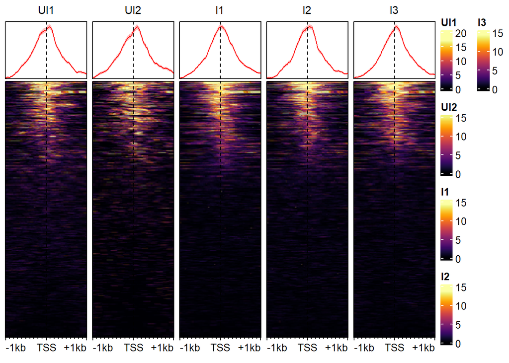

```r
plotEnrichedHeatmaps(smp,
                     axis_name="TSS",
                     multiScale=TRUE)
```

```r
# for the sake of speed, we'll plot only the first 2000 promoters
smp <- signal2Matrix(tracks2, promoterRegions[1:2000],
                       extend=1000, w=20,
                       limit=c(0,100),
                       smooth=TRUE)
```

```
## Reading preprocessed_data_paper/GSM5502605_MDX12_SOL893A14.bw
```

```
## Reading preprocessed_data_paper/GSM5502606_MDX24_SOL893A21.bw
```

```
## Reading preprocessed_data_paper/GSM5502607_MDX33_SOL893A28.bw
```

```
## Reading preprocessed_data_paper/GSM5502608_WT1_SOL1313A1.bw
```

```
## Reading preprocessed_data_paper/GSM5502609_WT2_SOL1313A3.bw
```

```
## Reading preprocessed_data_paper/GSM5502610_WT3_SOL1313A5.bw
```

```
## Reading preprocessed_data_paper/GSM5502611_WT4_SOL1313A8.bw
```

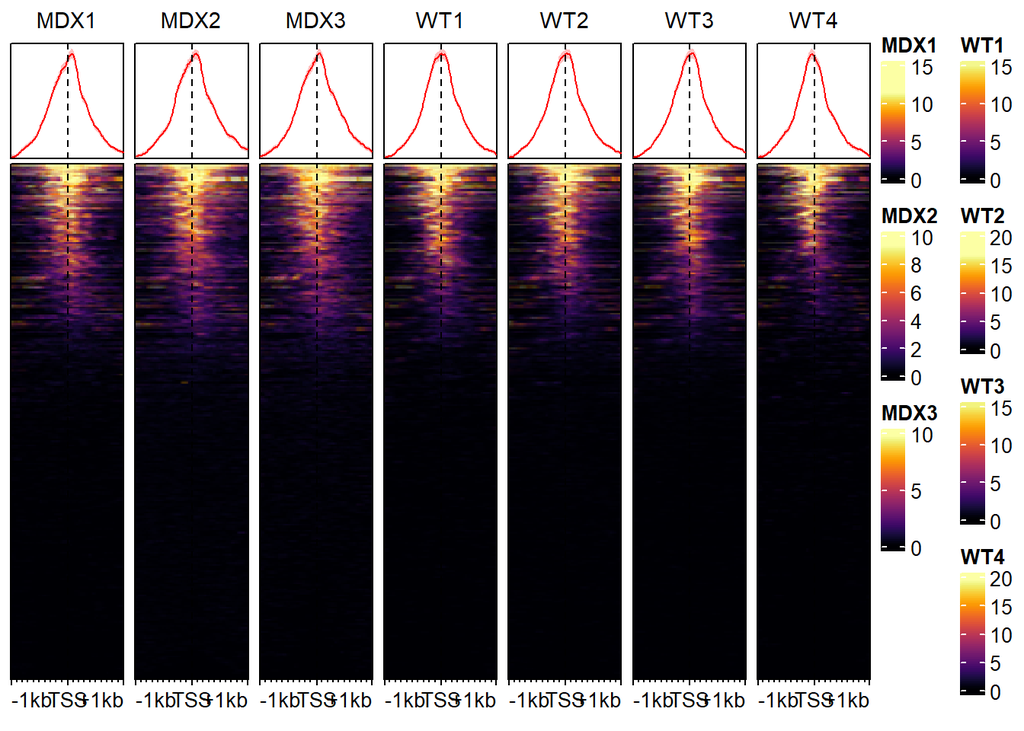

```r
plotEnrichedHeatmaps(smp,
                     axis_name="TSS",
                     multiScale=TRUE)
```